# Assignment 3

## Assignment 3

**TU Delft and WUR**  
**Q1 2024**  
**Instructor:** Theodoros Chatzivasileiadis  
**Instructor:** Hans Hoogenboom  
**TA:** Ka Yi Chua  
**[Metropolitan Data 1](https://jhoogenboom.github.io/spatial-data-science/_index.html)**

**This homework assignment document will guide you through five tasks in cleaning your data.**

1. Reading and Summarizing the Data.
2. Subsetting the Data.
3. Manage Missing Data.
4. Shape the Data.
5. Saving the Results.

# NB: From now on you should submit 1) your notebook with the answers, remember that comments are good practice, 2) a working Git page with your assignment

## Exercise 1: Loading the data:

- Load the `goodreads.csv` file into Python
- Explore it by looking at first and last 5 rows
- Change the column names to `["rating", 'review_count', 'isbn', 'booktype','author_url', 'year', 'genre_urls', 'dir','rating_count', 'name']`

```python
# your code here
# use many cells if you like to structure your code well

%matplotlib inline
import numpy as np
import matplotlib.pyplot as plt
import pandas as pd
import seaborn as sns
```

```python
#Read the data into a dataframe
df = pd.read_csv("./data/goodreads.csv", encoding='utf-8')

#Look at first 5 rows
df.head()
```

|  | 4.40 | 136455 | 0439023483 | good_reads:book | https://www.goodreads.com/author/show/153394.Suzanne_Collins | 2008 | /genres/young-adult\|/genres/science-fiction\|/genres/dystopia\|/genres/fantasy\|/genres/science-fiction\|/genres/romance\|/genres/adventure\|/genres/book-club\|/genres/young-adult\|/genres/teen\|/gen… | dir01/2767052-the-hunger-games.html | 2958974 | The Hunger Games (The Hunger Games, #1) |
| --- | --- | --- | --- | --- | --- | --- | --- | --- | --- | --- |
| 0 | 4.41 | 16648.0 | 0439358078 | good_reads:book | https://www.goodreads.com/author/show/1077326.... | 2003.0 | /genres/fantasy\|/genres/young-adult\|/genres/fi... | dir01/2.Harry_Potter_and_the_Order_of_the_Phoe... | 1284478.0 | Harry Potter and the Order of the Phoenix (Har... |
| 1 | 3.56 | 85746.0 | 0316015849 | good_reads:book | https://www.goodreads.com/author/show/941441.S... | 2005.0 | /genres/young-adult\|/genres/fantasy\|/genres/ro... | dir01/41865.Twilight.html | 2579564.0 | Twilight (Twilight, #1) |
| 2 | 4.23 | 47906.0 | 0061120081 | good_reads:book | https://www.goodreads.com/author/show/1825.Har... | 1960.0 | /genres/classics\|/genres/fiction\|/genres/histo... | dir01/2657.To_Kill_a_Mockingbird.html | 2078123.0 | To Kill a Mockingbird |
| 3 | 4.23 | 34772.0 | 0679783261 | good_reads:book | https://www.goodreads.com/author/show/1265.Jan... | 1813.0 | /genres/classics\|/genres/fiction\|/genres/roman... | dir01/1885.Pride_and_Prejudice.html | 1388992.0 | Pride and Prejudice |
| 4 | 4.25 | 12363.0 | 0446675539 | good_reads:book | https://www.goodreads.com/author/show/11081.Ma... | 1936.0 | /genres/classics\|/genres/historical-fiction\|/g... | dir01/18405.Gone_with_the_Wind.html | 645470.0 | Gone with the Wind |

```python
#Look at last 5 rows
df.tail()
```

|  | 4.40 | 136455 | 0439023483 | good_reads:book | https://www.goodreads.com/author/show/153394.Suzanne_Collins | 2008 | /genres/young-adult\|/genres/science-fiction\|/genres/dystopia\|/genres/fantasy\|/genres/science-fiction\|/genres/romance\|/genres/adventure\|/genres/book-club\|/genres/young-adult\|/genres/teen\|/gen… | dir01/2767052-the-hunger-games.html | 2958974 | The Hunger Games (The Hunger Games, #1) |
| --- | --- | --- | --- | --- | --- | --- | --- | --- | --- | --- |
| 5994 | 4.17 | 2226.0 | 0767913736 | good_reads:book | https://www.goodreads.com/author/show/44565.Ca... | 2005.0 | /genres/history\|/genres/non-fiction\|/genres/bi... | dir60/78508.The_River_of_Doubt.html | 16618.0 | The River of Doubt |
| 5995 | 3.99 | 775.0 | 1416909427 | good_reads:book | https://www.goodreads.com/author/show/151371.J... | 2006.0 | /genres/young-adult\|/genres/realistic-fiction\|... | dir60/259068.Shug.html | 6179.0 | Shug |
| 5996 | 3.78 | 540.0 | 1620612321 | good_reads:book | https://www.goodreads.com/author/show/5761314.... | 2012.0 | /genres/contemporary\|/genres/romance\|/genres/y... | dir60/13503247-flawed.html | 2971.0 | Flawed |
| 5997 | 3.91 | 281.0 | NaN | good_reads:book | https://www.goodreads.com/author/show/1201952.... | 2006.0 | /genres/religion\|/genres/islam\|/genres/religio... | dir60/2750008.html | 3083.0 | Ø£Ø³Ø¹Ø¯ Ø§Ù Ø±Ø£Ø© ÙÙ Ø§ÙØ¹Ø§ÙÙ |
| 5998 | 4.35 | 61.0 | 0786929081 | good_reads:book | https://www.goodreads.com/author/show/1023510.... | 2001.0 | /genres/fiction\|/genres/fantasy\|/genres/magic\|... | dir60/66677.Legacy_of_the_Drow_Collector_s_Edi... | 3982.0 | Legacy of the Drow Collector's Edition (Legacy... |

```python
#Change column names to ['rating', ....]

df=pd.read_csv("data/goodreads.csv", header=None,
               names=["rating", 'review_count', 'isbn', 'booktype','author_url', 'year', 'genre_urls', 'dir','rating_count', 'name'],
)

#Examine the first few rows of the dataframe
df.head()
```

|  | rating | review_count | isbn | booktype | author_url | year | genre_urls | dir | rating_count | name |
| --- | --- | --- | --- | --- | --- | --- | --- | --- | --- | --- |
| 0 | 4.40 | 136455.0 | 0439023483 | good_reads:book | https://www.goodreads.com/author/show/153394.S... | 2008.0 | /genres/young-adult\|/genres/science-fiction\|/g... | dir01/2767052-the-hunger-games.html | 2958974.0 | The Hunger Games (The Hunger Games, #1) |
| 1 | 4.41 | 16648.0 | 0439358078 | good_reads:book | https://www.goodreads.com/author/show/1077326.... | 2003.0 | /genres/fantasy\|/genres/young-adult\|/genres/fi... | dir01/2.Harry_Potter_and_the_Order_of_the_Phoe... | 1284478.0 | Harry Potter and the Order of the Phoenix (Har... |
| 2 | 3.56 | 85746.0 | 0316015849 | good_reads:book | https://www.goodreads.com/author/show/941441.S... | 2005.0 | /genres/young-adult\|/genres/fantasy\|/genres/ro... | dir01/41865.Twilight.html | 2579564.0 | Twilight (Twilight, #1) |
| 3 | 4.23 | 47906.0 | 0061120081 | good_reads:book | https://www.goodreads.com/author/show/1825.Har... | 1960.0 | /genres/classics\|/genres/fiction\|/genres/histo... | dir01/2657.To_Kill_a_Mockingbird.html | 2078123.0 | To Kill a Mockingbird |
| 4 | 4.23 | 34772.0 | 0679783261 | good_reads:book | https://www.goodreads.com/author/show/1265.Jan... | 1813.0 | /genres/classics\|/genres/fiction\|/genres/roman... | dir01/1885.Pride_and_Prejudice.html | 1388992.0 | Pride and Prejudice |

## Exercise 2: Subsetting the data

- Subset the data by creating new dataframe only with `["rating", 'isbn', 'author_url', 'year', 'genre_urls', 'name']`

```python
# your code here
# use many cells if you like to structure your code well

df2= df[["rating", 'isbn', 'author_url', 'year', 'genre_urls', 'name']]
df2.head()
```

|  | rating | isbn | author_url | year | genre_urls | name |
| --- | --- | --- | --- | --- | --- | --- |
| 0 | 4.40 | 0439023483 | https://www.goodreads.com/author/show/153394.S... | 2008.0 | /genres/young-adult\|/genres/science-fiction\|/g... | The Hunger Games (The Hunger Games, #1) |
| 1 | 4.41 | 0439358078 | https://www.goodreads.com/author/show/1077326.... | 2003.0 | /genres/fantasy\|/genres/young-adult\|/genres/fi... | Harry Potter and the Order of the Phoenix (Har... |
| 2 | 3.56 | 0316015849 | https://www.goodreads.com/author/show/941441.S... | 2005.0 | /genres/young-adult\|/genres/fantasy\|/genres/ro... | Twilight (Twilight, #1) |
| 3 | 4.23 | 0061120081 | https://www.goodreads.com/author/show/1825.Har... | 1960.0 | /genres/classics\|/genres/fiction\|/genres/histo... | To Kill a Mockingbird |
| 4 | 4.23 | 0679783261 | https://www.goodreads.com/author/show/1265.Jan... | 1813.0 | /genres/classics\|/genres/fiction\|/genres/roman... | Pride and Prejudice |

## Exercise 3: Manage Missing Data

We’ve got a number of ways in general of dealing with missing data. These involve

1. Dropping off cases (or rows) in the data with any missing variables
2. Excluding variables in the data with any missing data
3. Selectively choosing indicators with only a limited amount of missing data
4. Replacing missing variables with averages, or other representative values
5. Creating a separate model to predict missing data
- Count the missing values in each column
- Manage the missing values (delete or replace values or leave them as they are) and briefly explain your choice for each column

```python
# your code here
# use many cells if you like to structure your code well

#Get a sense of how many missing values there are in the dataframe.
print(np.sum([df2.rating.isnull()]))
print(np.sum([df2.isbn.isnull()]))
print(np.sum([df2.author_url.isnull()]))
print(np.sum([df2.year.isnull()]))
print(np.sum([df2.genre_urls.isnull()]))
print(np.sum([df2.name.isnull()]))
```

```
2
477
2
7
62
2
```

```python
#two names are unknown and there is no other information available in the dataframe to deduce which name corresponds with tose rows
# Therefore, I decided to drop the NaN values as it is not deducable and to clean the data
df2 = df2.dropna(subset=['name'])
print(np.sum([df2.name.isnull()]))
```

```
0
```

```python
# As you can see, the rows that were filled with NaN for the 'rating' column were the same rows as name column that we dropped.
# Thus for both columns the NaN rows are dropped with the previous code.
df2[df2.rating.isnull()]
```

|  | rating | isbn | author_url | year | genre_urls | name |
| --- | --- | --- | --- | --- | --- | --- |

```python
# #Second column is: 'year'

df2[df2.year.isnull()]
```

|  | rating | isbn | author_url | year | genre_urls | name |
| --- | --- | --- | --- | --- | --- | --- |
| 2442 | 4.23 | NaN | https://www.goodreads.com/author/show/623606.A... | NaN | /genres/religion\|/genres/islam\|/genres/non-fic... | La Tahzan |
| 2869 | 4.61 | NaN | https://www.goodreads.com/author/show/8182217.... | NaN | NaN | My Death Experiences - A Preacherâs 18 Apoca... |
| 5572 | 3.71 | 8423336603 | https://www.goodreads.com/author/show/285658.E... | NaN | /genres/fiction | Ãrase una vez el amor pero tuve que matarlo. ... |
| 5658 | 4.32 | NaN | https://www.goodreads.com/author/show/25307.Ro... | NaN | /genres/fantasy\|/genres/fantasy\|/genres/epic-f... | Assassin's Apprentice / Royal Assassin (Farsee... |
| 5683 | 4.56 | NaN | https://www.goodreads.com/author/show/3097905.... | NaN | /genres/fantasy\|/genres/young-adult\|/genres/ro... | Tiger's Dream (The Tiger Saga, #5) |

```python
# Looked up the years and ISBN of those NaN values

# 2002, 9789960974880

# My Death Experiences - A Preacherâs 18 Apoca... religie|spiritualiteit|Filosofie, 2014, ?

# 2004

# 1995, 9780007562251

# 2018, 1979597057
```

```python
#Changing years by hand. I looked up the years for the NaN values.

df2.loc[2442, 'year'] = 2002
print(df2.loc[2442])
```

```
rating                                                     4.23
isbn                                                        NaN
author_url    https://www.goodreads.com/author/show/623606.A...
year                                                     2002.0
genre_urls    /genres/religion|/genres/islam|/genres/non-fic...
name                                                  La Tahzan
Name: 2442, dtype: object
```

```python
df2.loc[2869, 'year'] = 2014
df2.loc[5572, 'year'] = 2004
df2.loc[5658, 'year'] = 1995
df2.loc[5683, 'year'] = 2018

df2[df2.year.isnull()]
```

|  | rating | isbn | author_url | year | genre_urls | name |
| --- | --- | --- | --- | --- | --- | --- |

```python
#Convert year to integers instead of floats
df2.year=df2.year.astype(int)
```

```python
#Third column is: 'isbn'!!!!!!!!!!!!!!!!!!!!!!!!!!!!!!!!!!!!!!!!!!!!!!!!!!!!!!!!!!!

df2[df2.isbn.isnull()]
```

|  | rating | isbn | author_url | year | genre_urls | name |
| --- | --- | --- | --- | --- | --- | --- |
| 16 | 3.92 | NaN | https://www.goodreads.com/author/show/498072.A... | 2003 | /genres/fiction\|/genres/romance\|/genres/fantas... | The Time Traveler's Wife |
| 49 | 3.85 | NaN | https://www.goodreads.com/author/show/5152.Vla... | 1955 | /genres/classics\|/genres/fiction\|/genres/liter... | Lolita |
| 85 | 4.16 | NaN | https://www.goodreads.com/author/show/137902.R... | 2007 | /genres/young-adult\|/genres/teen\|/genres/young... | Vampire Academy (Vampire Academy, #1) |
| 116 | 3.92 | NaN | https://www.goodreads.com/author/show/957894.A... | 1942 | /genres/classics\|/genres/fiction\|/genres/philo... | The Stranger |
| 156 | 4.03 | NaN | https://www.goodreads.com/author/show/4785.Ale... | 1843 | /genres/classics\|/genres/fiction\|/genres/histo... | The Three Musketeers |
| ... | ... | ... | ... | ... | ... | ... |
| 5972 | 4.19 | NaN | https://www.goodreads.com/author/show/4586597.... | 2011 | /genres/romance\|/genres/romance\|/genres/contem... | Perfection (Neighbor from Hell, #2) |
| 5976 | 4.23 | NaN | https://www.goodreads.com/author/show/5160667.... | 2014 | /genres/romance\|/genres/science-fiction\|/genre... | Transcendence |
| 5977 | 4.03 | NaN | https://www.goodreads.com/author/show/5769580.... | 1987 | /genres/fiction\|/genres/novels\|/genres/literat... | Ø§ÙØªÙÙ |
| 5991 | 4.20 | NaN | https://www.goodreads.com/author/show/1112683._ | 2009 | /genres/novels\|/genres/fiction\|/genres/religio... | Ø£ÙÙØ§Ø ÙØ¯Ø³Ø± |
| 5998 | 3.91 | NaN | https://www.goodreads.com/author/show/1201952.... | 2006 | /genres/religion\|/genres/islam\|/genres/religio... | Ø£Ø³Ø¹Ø¯ Ø§Ù Ø±Ø£Ø© ÙÙ Ø§ÙØ¹Ø§ÙÙ |

475 rows × 6 columns

```python
# ISBN of the NaN values

# Time travelars wife: 9780241568521
# Lolita: 9780241951644
# Vampire academy: 9780141932064
# The stranger: 9780679720201
# The three musketeers: 9798624625891
# Perfection: 1479338354
# Transcendence: 1495416046

#5977-5991-5998 - fill in 0
```

```python
df2.loc[16, 'isbn'] = 9780241568521
df2.loc[49, 'isbn'] = 9780241951644
df2.loc[85, 'isbn'] = 9780141932064
df2.loc[116, 'isbn'] = 9780679720201
df2.loc[156, 'isbn'] = 9798624625891
df2.loc[5972, 'isbn'] = 1479338354
df2.loc[5976, 'isbn'] = 1495416046
df2.loc[5977, 'isbn'] = 0
df2.loc[5991, 'isbn'] = 0
df2.loc[5998, 'isbn'] = 0


df2.loc[195, 'isbn'] = 9789000376544
df2.loc[299, 'isbn'] = 9782290389096
df2.loc[301, 'isbn'] = 9788178987354
df2.loc[308, 'isbn'] = 9780679732259
df2.loc[444, 'isbn'] = 9780008629137
df2.loc[5882, 'isbn'] = 9780991379613
df2.loc[5900, 'isbn'] = 9786026940148
df2.loc[5942, 'isbn'] = 9780008158866
df2.loc[5944, 'isbn'] = 9792285520
df2.loc[5964, 'isbn'] = 1592120539

df2[df2.isbn.isnull()]

##Are there more isbn with NaN?
```

|  | rating | isbn | author_url | year | genre_urls | name |
| --- | --- | --- | --- | --- | --- | --- |
| 529 | 4.25 | NaN | https://www.goodreads.com/author/show/346732.G... | 2011 | /genres/fantasy\|/genres/fiction\|/genres/fantas... | A Dance with Dragons (A Song of Ice and Fire, #5) |
| 561 | 3.90 | NaN | https://www.goodreads.com/author/show/2313.Lou... | 1993 | /genres/fiction\|/genres/historical-fiction\|/ge... | Captain Corelli's Mandolin |
| 592 | 4.33 | NaN | https://www.goodreads.com/author/show/5430144.... | 2012 | /genres/romance\|/genres/new-adult\|/genres/youn... | Slammed (Slammed, #1) |
| 610 | 4.09 | NaN | https://www.goodreads.com/author/show/155517.I... | 1979 | /genres/fiction\|/genres/classics\|/genres/europ... | If on a Winter's Night a Traveler |
| 648 | 4.13 | NaN | https://www.goodreads.com/author/show/4126827.... | 2011 | /genres/young-adult\|/genres/fantasy\|/genres/pa... | The Unbecoming of Mara Dyer (Mara Dyer, #1) |
| ... | ... | ... | ... | ... | ... | ... |
| 5858 | 4.09 | NaN | https://www.goodreads.com/author/show/2994581._ | 2014 | /genres/novels\|/genres/romantic\|/genres/litera... | ÙÙØ¨ØªØ§ |
| 5859 | 4.17 | NaN | https://www.goodreads.com/author/show/1349023.... | 2007 | /genres/fiction\|/genres/fantasy | Gone |
| 5866 | 4.03 | NaN | https://www.goodreads.com/author/show/696355.I... | 2008 | /genres/romance\|/genres/asian-literature\|/genr... | Winter in Tokyo |
| 5872 | 4.18 | NaN | https://www.goodreads.com/author/show/4833990.... | 2012 | /genres/romance\|/genres/new-adult\|/genres/cont... | That Wedding (That Boy, #2) |
| 5880 | 4.61 | NaN | https://www.goodreads.com/author/show/4942228.... | 2010 | /genres/romance\|/genres/m-m-romance\|/genres/sc... | The Interludes (In the company of shadows, #3) |

455 rows × 6 columns

```python
df2[df2.author_url.isnull()]
```

|  | rating | isbn | author_url | year | genre_urls | name |
| --- | --- | --- | --- | --- | --- | --- |

```python
#Fourth column is: 'author url'

#Problem here is that the author is together with the url. We should try to seperate those and isolate the author name.
#Get the first author_url
test_string = df2.author_url[0]
test_string
```

```
'https://www.goodreads.com/author/show/153394.Suzanne_Collins'
```

```python
#Test out some string operations to isolate the author name

test_string.split('/')[-1].split('.')[1:][0]
```

```
'Suzanne_Collins'
```

```python
# Write a function that accepts an author url and returns the author's name based on your experimentation above
def get_author(url):

    name = url.split('/')[-1].split('.')[1:][0]

    return name
```

```python
#Apply the get_author function to the 'author_url' column using '.map'
#and add a new column 'author' to store the names
df2['author'] = df2.author_url.map(get_author)
df2.author[0:5]
```

```
0    Suzanne_Collins
1        J_K_Rowling
2    Stephenie_Meyer
3         Harper_Lee
4        Jane_Austen
Name: author, dtype: object
```

```python
df2[df2.genre_urls.isnull()]
```

|  | rating | isbn | author_url | year | genre_urls | name | author |
| --- | --- | --- | --- | --- | --- | --- | --- |
| 953 | 4.56 | 1477276068 | https://www.goodreads.com/author/show/6621980.... | 2012 | NaN | Crossing the Seas | Yuehai_Xiao |
| 1515 | 4.56 | NaN | https://www.goodreads.com/author/show/394525.T... | 2013 | NaN | Crashing Down to Earth | Terry_Reid |
| 1693 | 4.21 | NaN | https://www.goodreads.com/author/show/3110785._ | 2009 | NaN | Ð¡Ð»ÑÐ½ÑÐµ Ð½ÐµÐ´Ð¾ÑÐµÐ³Ð°ÐµÐ¼Ð¾ | _ |
| 1752 | 3.85 | 140921818X | https://www.goodreads.com/author/show/7337562.... | 13 | NaN | The Day Jesus Rode Into Croydon | Kirk_St_Moritz |
| 1942 | 4.66 | 0992382009 | https://www.goodreads.com/author/show/7574275.... | 2014 | NaN | Letters from your soul | Victor_Noble |
| 2034 | 4.92 | 147930414X | https://www.goodreads.com/author/show/6467808.... | 2012 | NaN | Happy Halloween | Othen_Donald_Dale_Cummings |
| 2067 | 4.16 | 0804844399 | https://www.goodreads.com/author/show/6894841.... | 2012 | NaN | A Capitalist in North Korea | Felix_Abt |
| 2145 | 5.00 | 1300589469 | https://www.goodreads.com/author/show/6906561.... | 2012 | NaN | A Book About Absolutely Nothing. | I_M_Nobody |
| 2170 | 4.65 | NaN | https://www.goodreads.com/author/show/6565853.... | 2012 | NaN | Curse of The Salute | Anastacia_Moore |
| 2190 | 4.33 | 0987434853 | https://www.goodreads.com/author/show/4443219.... | 2013 | NaN | Life Song | Christine_M_Knight |
| 2476 | 3.53 | NaN | https://www.goodreads.com/author/show/5139623.... | 2013 | NaN | Miscellaneous Stuff & Stuff | Jim_Henry |
| 2734 | 4.08 | 0192833987 | https://www.goodreads.com/author/show/128382.L... | 1869 | NaN | War and Peace | Leo_Tolstoy |
| 2865 | 4.93 | 9789898541 | https://www.goodreads.com/author/show/7458878.... | 2012 | NaN | Laços fortes e decisões difíceis | Gra_a_Jacinto |
| 2868 | 4.94 | NaN | https://www.goodreads.com/author/show/8127793.... | 2014 | NaN | Nik Nassa & the Mark of Destiny | A_J_Salt |
| 2869 | 4.61 | NaN | https://www.goodreads.com/author/show/8182217.... | 2014 | NaN | My Death Experiences - A Preacherâs 18 Apoca... | Zion_Odum |
| 2877 | 3.53 | NaN | https://www.goodreads.com/author/show/8193887.... | 2014 | NaN | Ø§ÙØµÙØª Ø±ÙØ | Huda_Aweys |
| 2903 | 5.00 | 0983002282 | https://www.goodreads.com/author/show/6589034.... | 2012 | NaN | Obscured Darkness (Family Secrets #2) | Rebekah_McClew |
| 2909 | 5.00 | 0983002215 | https://www.goodreads.com/author/show/6589034.... | 2011 | NaN | Family Secrets | Rebekah_McClew |
| 2920 | 4.93 | 1453634819 | https://www.goodreads.com/author/show/4808225.... | 2010 | NaN | The Years Distilled | Dennis_Sharpe |
| 2928 | 4.73 | 0983002274 | https://www.goodreads.com/author/show/6589034.... | 2012 | NaN | Mortal | Rebekah_McClew |
| 3225 | 4.00 | NaN | https://www.goodreads.com/author/show/6520851.... | 2012 | NaN | Take a Deep Breath - 21 Top Tips for Relaxed, ... | Michal_Siwiec |
| 3229 | 4.40 | 1625108737 | https://www.goodreads.com/author/show/6978127.... | 2013 | NaN | The Mystery of Revenge | G_X_Chen |
| 3238 | 4.35 | NaN | https://www.goodreads.com/author/show/7243654.... | 2013 | NaN | The Real Book of the Dead | Collette_Sinclaire |
| 3258 | 4.63 | NaN | https://www.goodreads.com/author/show/7058502.... | 2013 | NaN | The Keeper (The Keeper, #3) | O_L_Ramos |
| 3289 | 4.61 | NaN | https://www.goodreads.com/author/show/7243654.... | 2013 | NaN | Messages From Heaven | Collette_Sinclaire |
| 3688 | 4.53 | NaN | https://www.goodreads.com/author/show/6440482.... | 2012 | NaN | The Oaks (Royal Oaks, #1) | Jessica_Smith |
| 3786 | 4.00 | NaN | https://www.goodreads.com/author/show/7843984.... | 2014 | NaN | The Eagle's Secret | Erez_Aharoni |
| 3803 | 3.98 | 1608622835 | https://www.goodreads.com/author/show/4875841.... | 2011 | NaN | Hillbilly Tales from the Smoky Mountains - And... | Patricia_H_Graham |
| 3868 | 4.43 | 1606191934 | https://www.goodreads.com/author/show/2941486.... | 2012 | NaN | The Case of the Cosmological Killer (Displaced... | Stephanie_Osborn |
| 4383 | 4.29 | NaN | https://www.goodreads.com/author/show/5077755.... | 2011 | NaN | I am an Island | Jonathan_Culver |
| 4384 | 4.06 | NaN | https://www.goodreads.com/author/show/5831594.... | 2012 | NaN | Undying (Undying, #1) | Bernadette_Azizi |
| 4387 | 4.36 | 1494884631 | https://www.goodreads.com/author/show/7754245.... | 2014 | NaN | It's Not What You Think (It's Not What You Thi... | Ashley_Waelti |
| 4389 | 4.29 | NaN | https://www.goodreads.com/author/show/7801640.... | 2013 | NaN | We Got Zombies On The Lawn Again, Ma (Ax Hande... | Donnie_Smith |
| 4405 | 4.88 | NaN | https://www.goodreads.com/author/show/8433703.... | 2014 | NaN | My Two Cents | Ahmad_Baari |
| 4410 | 4.37 | NaN | https://www.goodreads.com/author/show/7380017.... | 2013 | NaN | Hard Up, Ardon #1 | Jimmy_Perrin |
| 4472 | 4.79 | NaN | https://www.goodreads.com/author/show/6585024.... | 2013 | NaN | Tilt (Dreams of Chaos #2) | Ashley_Chappell |
| 4473 | 5.00 | NaN | https://www.goodreads.com/author/show/6896621.... | 2012 | NaN | Patience's Love | Ronda_Paige |
| 4524 | 4.46 | NaN | https://www.goodreads.com/author/show/4808225.... | 2011 | NaN | Fresh | Dennis_Sharpe |
| 4763 | 4.56 | NaN | https://www.goodreads.com/author/show/4087195.... | 2010 | NaN | In the Name of Revenge (Ivanovich, #1) | Starr_Gardinier_Reina |
| 5411 | 4.25 | 1450556566 | https://www.goodreads.com/author/show/3335237.... | 2010 | NaN | A Terrace On The Tower Of Babel | Nelson_Caldwell |
| 5429 | 4.45 | NaN | https://www.goodreads.com/author/show/7373870.... | 2013 | NaN | It Comes Natural - Understanding Natural and I... | Marsha_Gujurati |
| 5433 | 4.60 | NaN | https://www.goodreads.com/author/show/8187644.... | 2014 | NaN | New Zigon - The Founder's Curse | Danelle_O_Donnell |
| 5435 | 4.48 | NaN | https://www.goodreads.com/author/show/5132169.... | 2014 | NaN | Bound Anthology | J_M_Walker |
| 5443 | 4.15 | 0982816308 | https://www.goodreads.com/author/show/4524500.... | 2010 | NaN | Secrets of Jewish Wealth Revealed! | Celso_Cukierkorn |
| 5458 | 4.25 | 1311059164 | https://www.goodreads.com/author/show/8507331.... | 2014 | NaN | Liliana | Author_Neva_Squires_Rodriguez |
| 5479 | 4.66 | NaN | https://www.goodreads.com/author/show/7456408.... | 2013 | NaN | Churning Waters | Meredith_T_Taylor |
| 5480 | 4.83 | 1495416739 | https://www.goodreads.com/author/show/7399883.... | 2014 | NaN | This Land of Streams | Maria_Johnsen |
| 5494 | 3.81 | NaN | https://www.goodreads.com/author/show/5077755.... | 2008 | NaN | Huey Lambert's Walking Nuclear Circus | Jonathan_Culver |
| 5498 | 4.80 | 1933455098 | https://www.goodreads.com/author/show/5834131.... | 2012 | NaN | Syrian Folktales | Muna_Imady |
| 5500 | 4.71 | NaN | https://www.goodreads.com/author/show/5895074.... | 2011 | NaN | Fantacia (Voxian, #1) | Ruth_Watson_Morris |
| 5516 | 4.62 | 0974056049 | https://www.goodreads.com/author/show/503388.B... | 2006 | NaN | The Peace of the Spirit Within | Belsebuub |
| 5532 | 4.86 | 1477504540 | https://www.goodreads.com/author/show/5989528.... | 2013 | NaN | Call Of The Lost Ages | Subhajit_Ganguly |
| 5560 | 4.00 | NaN | https://www.goodreads.com/author/show/7518486._ | 2013 | NaN | Ø§Ù ÙØ§Ù ÙØ¯Ù Ø§Ø¡ | _ |
| 5565 | 4.50 | NaN | https://www.goodreads.com/author/show/8262567.... | 2014 | NaN | Five Years - The Meeting | Leonard_Belmont |
| 5584 | 4.75 | 1481959824 | https://www.goodreads.com/author/show/5100743.... | 2013 | NaN | Why Not-World | Alexei_Maxim_Russell |
| 5618 | 4.44 | 1495907791 | https://www.goodreads.com/author/show/7399883.... | 2014 | NaN | The Afternoon When She Died | Maria_Johnsen |
| 5692 | 5.00 | NaN | https://www.goodreads.com/author/show/5989528.... | 2012 | NaN | Abstraction In Theory - Laws Of Physical Trans... | Subhajit_Ganguly |
| 5717 | 4.71 | NaN | https://www.goodreads.com/author/show/5838022.... | 2012 | NaN | American Amaranth | J_R_Ortiz |
| 5729 | 4.83 | NaN | https://www.goodreads.com/author/show/7058502.... | 2014 | NaN | The Keeper (The Keeper, #5) | O_L_Ramos |
| 5778 | 4.63 | NaN | https://www.goodreads.com/author/show/4808225.... | 2010 | NaN | (Un) Spoken | Dennis_Sharpe |

```python
df2['genre_urls'] = df2['genre_urls'].fillna(0)
```

```python
df2[df2.genre_urls.isnull()]
```

|  | rating | isbn | author_url | year | genre_urls | name | author |
| --- | --- | --- | --- | --- | --- | --- | --- |

```python
#Fifth column is 'genre'
#So for genre the same applies as the column of the authors meaning that we have to isolate the genre from the url.
df.genre_urls.head()
```

```
0    /genres/young-adult|/genres/science-fiction|/g...
1    /genres/fantasy|/genres/young-adult|/genres/fi...
2    /genres/young-adult|/genres/fantasy|/genres/ro...
3    /genres/classics|/genres/fiction|/genres/histo...
4    /genres/classics|/genres/fiction|/genres/roman...
Name: genre_urls, dtype: object
```

```python
#Examine some examples of genre_urls

#Test out some string operations to isolate the genre name
test_genre_string=df.genre_urls[0]
genres=test_genre_string.strip().split('|')
for e in genres:
    print(e.split('/')[-1])
    "|".join(genres)
```

```
young-adult
science-fiction
dystopia
fantasy
science-fiction
romance
adventure
book-club
young-adult
teen
apocalyptic
post-apocalyptic
action
```

```python
def split_and_join_genres(url):

    genres=url.strip().split('|')
    genres=[e.split('/')[-1] for e in genres]
    return "|".join(genres)
```

```python
def split_and_join_genres(urls):
    # Ensure the input is a string
    if isinstance(urls, str):
        # Strip any surrounding whitespace, split by '|', and process each genre
        genres = urls.strip().split('|')
        # For each genre, split by '/' and take the last part
        processed_genres = [genre.split('/')[-1] for genre in genres]
        # Join the processed genres with '|'
        return '|'.join(processed_genres)
    else:
        # Handle non-string cases (e.g., return empty string or another default value)
        return ''
```

```python
split_and_join_genres("/genres/young-adult|/genres/science-fiction")
```

```
'young-adult|science-fiction'
```

```python
split_and_join_genres("")
```

```
''
```

```python
df2['genres']=df2.genre_urls.map(split_and_join_genres)
df2.head()
```

|  | rating | isbn | author_url | year | genre_urls | name | author | genres |
| --- | --- | --- | --- | --- | --- | --- | --- | --- |
| 0 | 4.40 | 0439023483 | https://www.goodreads.com/author/show/153394.S... | 2008 | /genres/young-adult\|/genres/science-fiction\|/g... | The Hunger Games (The Hunger Games, #1) | Suzanne_Collins | young-adult\|science-fiction\|dystopia\|fantasy\|s... |
| 1 | 4.41 | 0439358078 | https://www.goodreads.com/author/show/1077326.... | 2003 | /genres/fantasy\|/genres/young-adult\|/genres/fi... | Harry Potter and the Order of the Phoenix (Har... | J_K_Rowling | fantasy\|young-adult\|fiction\|fantasy\|magic\|chil... |
| 2 | 3.56 | 0316015849 | https://www.goodreads.com/author/show/941441.S... | 2005 | /genres/young-adult\|/genres/fantasy\|/genres/ro... | Twilight (Twilight, #1) | Stephenie_Meyer | young-adult\|fantasy\|romance\|paranormal\|vampire... |
| 3 | 4.23 | 0061120081 | https://www.goodreads.com/author/show/1825.Har... | 1960 | /genres/classics\|/genres/fiction\|/genres/histo... | To Kill a Mockingbird | Harper_Lee | classics\|fiction\|historical-fiction\|academic\|s... |
| 4 | 4.23 | 0679783261 | https://www.goodreads.com/author/show/1265.Jan... | 1813 | /genres/classics\|/genres/fiction\|/genres/roman... | Pride and Prejudice | Jane_Austen | classics\|fiction\|romance\|historical-fiction\|li... |

```python
#Delete genre_urls and author_url column

# del df2['genre_urls']
# del df2['author_url']

df2.columns
```

[output not shown]

## Exercise 4: Shape the data

- Parse the `author_url` to create new column named `author`
- Sort the data by putting higher rates go first. If there are overlapping rates, try to put earlier years go first.
- **(Stretch Goal)** Examine how many books were published at each year and find lowest, highest rate of each year.

```python
# your code here
# use many cells if you like to structure your code well

#Parse the author url to create new column named author
df2['author'] = df2.author_url.map(get_author)
```

```python
#Sort data by putting higher rates go first
highest_rating = df2.sort_values(by = ['rating', 'year'], ascending=False)
highest_rating
```

[output not shown]

5998 rows × 6 columns

```python
df2[df2.year < 0].name
```

```
47                               The Odyssey
246                    The Iliad/The Odyssey
455                             The Republic
596                               The Aeneid
629                              Oedipus Rex
674                           The Art of War
746                        The Bhagavad Gita
777                                 Antigone
1233                       The Oedipus Cycle
1397                          Aesop's Fables
1398                   The Epic of Gilgamesh
1428                                   Medea
1815                            The Oresteia
1882         The Trial and Death of Socrates
2078    The History of the Peloponnesian War
2527                           The Histories
3133                          Complete Works
3274                  The Nicomachean Ethics
3757                              Lysistrata
4402                           The Symposium
4475                                 Apology
5367                          Five Dialogues
Name: name, dtype: object
```

```python
# Group by 'year' and aggregate the data
yearly_stats = df2.groupby('year').agg(
    books_published=('name', 'count'),  # Count number of books
    lowest_rating=('rating', 'min'),     # Find the lowest rating in each year
    highest_rating=('rating', 'max')     # Find the highest rating in each year
).reset_index()

# Display the statistics
yearly_stats
```

|  | year | books_published | lowest_rating | highest_rating |
| --- | --- | --- | --- | --- |
| 0 | -1500 | 1 | 3.60 | 3.60 |
| 1 | -800 | 2 | 3.68 | 4.01 |
| 2 | -560 | 1 | 4.03 | 4.03 |
| 3 | -512 | 1 | 3.92 | 3.92 |
| 4 | -500 | 1 | 4.06 | 4.06 |
| ... | ... | ... | ... | ... |
| 289 | 2011 | 374 | 2.00 | 5.00 |
| 290 | 2012 | 355 | 3.15 | 5.00 |
| 291 | 2013 | 276 | 2.90 | 4.93 |
| 292 | 2014 | 88 | 3.31 | 5.00 |
| 293 | 2018 | 1 | 4.56 | 4.56 |

294 rows × 4 columns

## Exercise 5: Saving the results

- Save the cleaned dataframe as 'hw-03-cleaned.csv' in data folder

```python
# your code here
# use many cells if you like to structure your code well

df2.to_csv("data/hw-03-cleaned.csv", index=False, header=True)
```

## Exercise 6: Investigate the relationship between the number of reviews and the average rating for books in the dataset cleaned-goodreads.csv procided.

- Calculate the correlation coefficient. Give me a short definition of this coefficient
- Create a scatter plot showing the relationship between these two features.
- Based on the plot and the correlation, provide a brief interpretation of the relationship.

### Python Tools: Use pandas and numpy for correlation, and matplotlib or seaborn for the scatter plot.

```python
df2.columns
```

```
Index(['rating', 'isbn', 'year', 'name', 'author', 'genres'], dtype='object')
```

```python
df.columns
```

```
Index(['rating', 'review_count', 'isbn', 'booktype', 'author_url', 'year',
       'genre_urls', 'dir', 'rating_count', 'name'],
      dtype='object')
```

```python
# your code here
# use many cells if you like to structure your code well

# Calculate the correlation matrix
correlation_matrix = df['review_count'].corr(df['rating'])
print(correlation_matrix)
```

```
-0.03816911084805154
```

```python
# the coefficient can range between -1 and 1. 1 is a perfect positive correlation; as one variable increases, the other also increases in perfect linear manner
# -1 is perfect negative correlation; as one variable decreases, the other also decreases
# 0 means there is no relationship between the variables
```

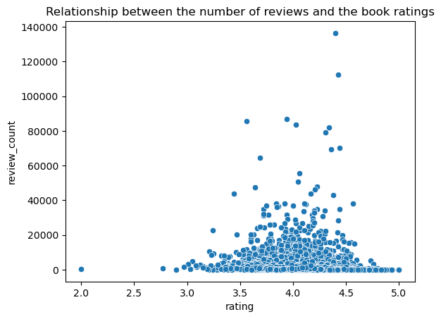

```python
sns.scatterplot(data=df, x="rating", y="review_count").set_title('Relationship between the number of reviews and the book ratings')
```

```python
# The pearson correlation value is -0.038 which suggests a very weak negative relationship. Meaning that as the number of reviews
# slightly increases, the ratings tend to slightly decreases. But this relationship is so weak that it is practically neglectable.
# So you can't predict the rating of a book just based on how many reviews it has.
```

## Exercise 7: Calculate the following descriptive statistics for the numerical features (e.g., number of reviews, average rating, etc.):

- Mean
- Median
- Standard Deviation
- Range
- Create a histogram or box plot for at least one of the numerical features, highlighting any skewness or outliers.

### Python Tools: Use pandas for data manipulation and matplotlib or seaborn for visualization.

```python
# your code here
# use many cells if you like to structure your code well

#int and float are numeric types
df.dtypes

# thus numeric columns are: 'rating', 'review_count', 'year', 'rating_count'
```

```
rating          float64
review_count    float64
isbn             object
booktype         object
author_url       object
year            float64
genre_urls       object
dir              object
rating_count    float64
name             object
dtype: object
```

```python
# Describing descriptive statistics of rating (Mean, std and range (min/max)) - so needed median
print("\nDescriptive statistics of Rating:\n")
stats_rating = df['rating'].describe()
print(stats_rating)
```

```
Descriptive statistics of Rating:

count    5998.000000
mean        4.042201
std         0.260661
min         2.000000
25%         3.870000
50%         4.050000
75%         4.210000
max         5.000000
Name: rating, dtype: float64
```

```python
print("\nDescriptive statistics of Review count:\n")
stats_revc = df['review_count'].describe()
print(stats_revc)
```

```
Descriptive statistics of Review count:

count      5998.000000
mean       2372.487162
std        5491.177007
min           0.000000
25%         389.250000
50%         932.500000
75%        2210.500000
max      136455.000000
Name: review_count, dtype: float64
```

```python
print("\nDescriptive statistics of Year:\n")
stats_year = df['year'].describe()
print(stats_year)
```

```
Descriptive statistics of Year:

count    5993.000000
mean     1969.085099
std       185.383169
min     -1500.000000
25%      1980.000000
50%      2002.000000
75%      2009.000000
max      2014.000000
Name: year, dtype: float64
```

```python
print("\nDescriptive statistics of Rating count:\n")
stats_rac = df['rating_count'].describe()
print(stats_rac)
```

```
Descriptive statistics of Rating count:

count    5.998000e+03
mean     5.114278e+04
std      1.375993e+05
min      5.000000e+00
25%      7.495250e+03
50%      1.806300e+04
75%      4.285325e+04
max      2.958974e+06
Name: rating_count, dtype: float64
```

```python
# calculate median of numeric columns

df[['rating', 'review_count', 'year', 'rating_count']].median()
```

```
rating              4.05
review_count      932.50
year             2002.00
rating_count    18063.00
dtype: float64
```

```python
# Visualize

data_to_plot = df[['rating', 'review_count', 'year', 'rating_count']]
```

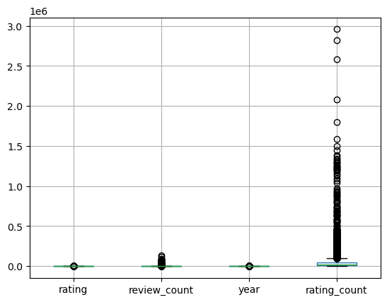

```python
data_to_plot.boxplot()
```

```python
# not smart to plot these variables in 1 plot because the y-as is not comparable in 1 plot
```

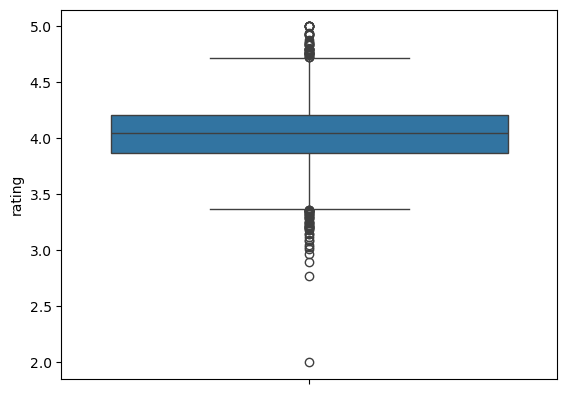

```python
sns.boxplot(df['rating'])
```

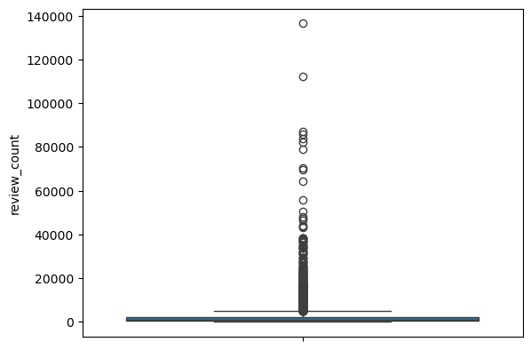

```python
sns.boxplot(df['review_count'])
```

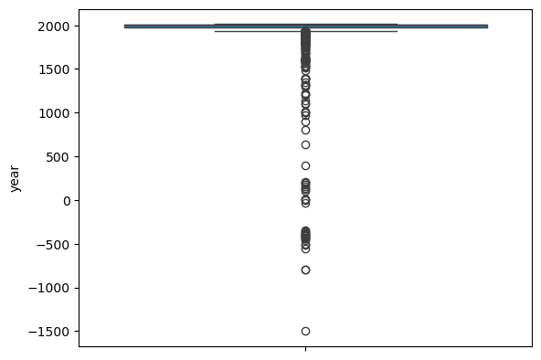

```python
sns.boxplot(df['year'])
```

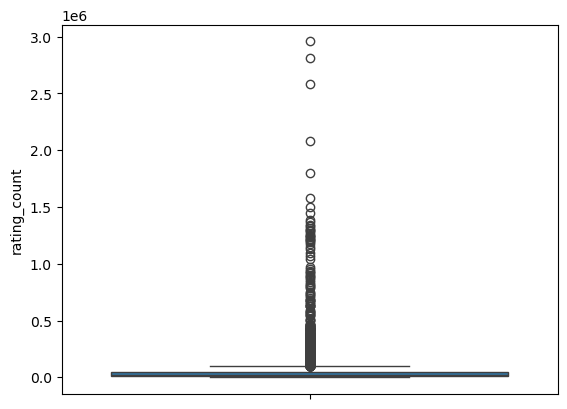

```python
sns.boxplot(df['rating_count'])
```

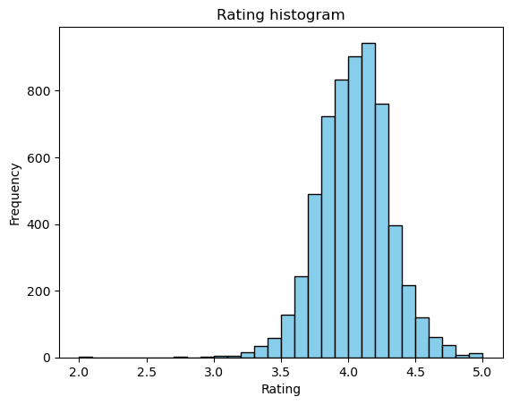

```python
plt.hist(df['rating'], bins=30, color='skyblue', edgecolor='black')
plt.xlabel('Rating')
plt.ylabel('Frequency')
plt.title('Rating histogram')
```

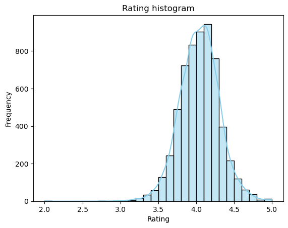

```python
sns.histplot(df['rating'], bins=30, kde=True, color='skyblue', edgecolor='black')
plt.xlabel('Rating')
plt.ylabel('Frequency')
plt.title('Rating histogram')
```

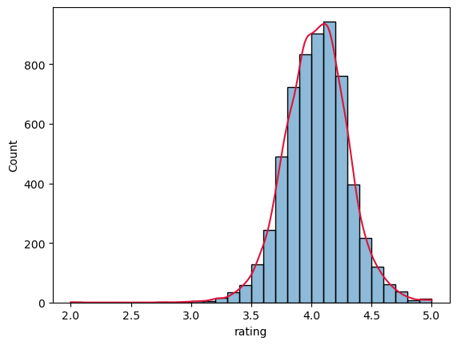

```python
ax = sns.histplot(data=df, bins=30, x="rating", kde=True)
ax.lines[0].set_color('crimson')
```

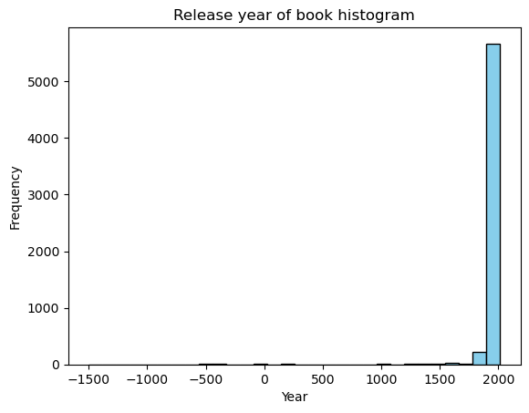

```python
plt.hist(df['year'], bins=30, color='skyblue', edgecolor='black')
plt.xlabel('Year')
plt.ylabel('Frequency')
plt.title('Release year of book histogram')
```